# Siete Herramientas de Calidad (QC)

Existen siete herramientas de coalidad (QC) que son fundamentales para organizar los datos en el proceso de gestión de la calidad

```python
import os

try:
  os.chdir('../Python/QCKentei3')
except:
  pass

path = os.getcwd()
```

```python
import numpy as np
import pandas as pd
import matplotlib.pyplot as plt

import gspread
from google.oauth2.service_account import Credentials
```

## 02-01 Diagrama de Pareto

### 1. ¿Qué es un diagrama de Pareto?

- Diagrama de Pareto: Es un gráfico que divide la cantidad de productos no conformes (cantidad de productos defectuosos), número de no conformidades (número de defectos), número de fallas o montos de pérdidas por categorías, ordenándolos de mayor a menor según el número de datos, y representados en un gráfico de barras junto con una curva acumulada.

### 2. Cómo hacer un diagrama de Pareto

#### Paso1:

Determinar el período y recolectar los datos.

#### Paso2:

Clasificar los datos según sus causas o contenidos.

#### Paso3:

Agrupar los datos por categoría y creer una tabla de resumen.

```python
SERVICE_ACCOUNT_FILE = "my-project-vscode-452201-249bdb033f8c.json"  # JSONファイルのパス
SCOPES = ["https://www.googleapis.com/auth/spreadsheets"]

credentials = Credentials.from_service_account_file(SERVICE_ACCOUNT_FILE, scopes=SCOPES)
client = gspread.authorize(credentials)

# スプレッドシートを開く（URLまたはスプレッドシートIDを使用）
SPREADSHEET_ID = "1kqN4PUhamo1jwqudnaHuaUSWvNX4tIbVTY5YU4g9r3A"
sheet = client.open_by_key(SPREADSHEET_ID).worksheet("Sheet6") # 最初のシートを取得

# データを取得
list_of_lists = sheet.get_all_records()
df = pd.DataFrame(list_of_lists)

df = df.set_index('Ítem no conforme')
df = df.astype({'Número de ítems no conformes':int, 'Número acumulado de ítems no conformes': int, 'Tasa (%)': float, 'Tasa acumulada (%)': float})

print('Tabla de resumen')
df
```

```
Tabla de resumen
```

| Ítem no conforme | Número de ítems no conformes | Número acumulado de ítems no conformes | Tasa (%) | Tasa acumulada (%) |
| --- | --- | --- | --- | --- |
| Acabado de superficie | 80 | 80 | 40.6 | 40.6 |
| Dimensiones | 50 | 130 | 66.0 | 66.0 |
| Grietas | 25 | 155 | 78.7 | 78.7 |
| Forma | 17 | 172 | 87.3 | 87.3 |
| Marcas de golpeo | 10 | 182 | 92.4 | 92.4 |
| Otro | 15 | 197 | 100.0 | 100.0 |

#### Paso4:

Crear un diagrama de Pareto

```python
def pareto_chart(df, title=""):
    fig, ax3 = plt.subplots(figsize=(6,5))
    data_num = len(df)

    accum_to_plot = [0] + df.iloc[:,3].tolist()

    ax3.bar(range(1, data_num + 1), df.iloc[:,0], align="edge", width=-1, edgecolor='k')
    ax3.set_xticklabels([])

    ax3.set_xticks([0.5 + i for i in range(data_num)], minor=True)
    ax3.set_xticklabels(df.index.tolist(), minor=True, rotation = -90)

    ymx = df.iloc[:,0].sum()

    ax3.set_ylim([0, ymx])
    ax3.tick_params(axis="x", which="major", direction="in")
    ax3.set_ylim([0, ymx])
    ax3.set_ylabel(df.columns[0])
    ax3.set_xlabel(df.index.name)

    ax4 = ax3.twinx()
    ax4.plot(range(data_num+1), accum_to_plot, c="k", marker="o")
    ax4.set_ylim([0, 100])
    ax4.set_xlim([0, data_num])
    ax4.set_ylabel("Tasa acumulada (%)")
    yticks = np.linspace(0, 100, 11)
    ax4.set_yticks(yticks)

    percent_labels = [str(i) + "%" for i in yticks]
    ax4.set_yticklabels(percent_labels)
    ax4.grid(True, which='both', axis='y')
    ax4.set_title("PARETO_CHART " + title )

    plt.subplots_adjust(left=0.2, right=0.8, bottom=0.40, top=0.92)

    plt.savefig("Graph3/pareto_2.png", format="png", dpi=300)
```

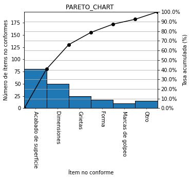

```python
pareto_chart(df)
```

### 3. Observar el efecto de la mejora

Si se crean diagramas de Pareto antes y después de la mejora, alineados lado a lado con la misma escala en el eje vertical, se podrá vísualizar el efecto de la majora.

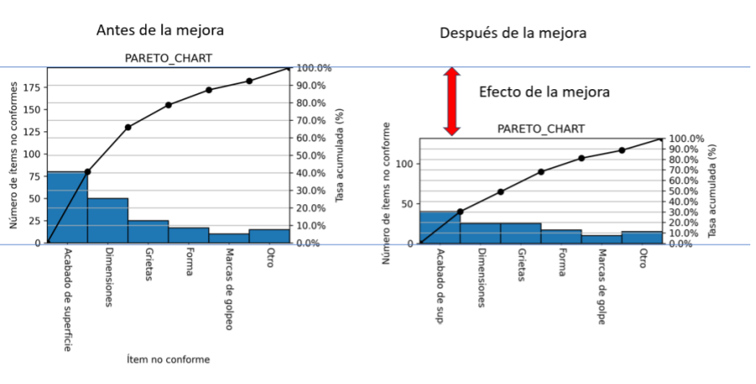

```python
from IPython.display import display
from PIL import Image

img = Image.open("Graph3/Pareto3.png")
display(img)
```

### 4. Puntos clave a observar

1. Cuando se crea un diagrama de Pareto y las barras tienen alturas similares, lo que dificulta la identificación de prioridades o puntos de mejora, es recomendable cambiar las categorías del eje horizontal o modificar la característica del eje vertical y volver a generarlo.
2. Si la barra de 'Otros' resulta ser la primera o segunda más alta, es necesario revisar del método de clasificación, incluyendo la forma en que se agrupan los elementos en 'Otros'.

## 2.1

A社では新し部品を８台の装置で製造している。それぞれの装置の停止時間を一か月にわたって調べたところ、表２．２のデータが得られた。

1. 停止時間の少ない３つの装置のデータをまとめて「その他」として、パレート図作成のための集計表２．３を完成させなさい。
2. 得られた集計表からパレート図をしなさい。

La empresa A fabrica una nueva pieza utilizando ocho equipos. Se registraron los tiempos de paro de cada equipo durante un mes, obteniendo los datos de la Tabla 2.2.

1. Complete la Tabla 2.3 de consolidación par la creación del diagrama de Pareto, agrupando los datos de los tres equpos con menor tiempo de paro bajo la categoría 'Otros'.
2. A partir de la tabla obtenida, elabore el diagrama de Pareto.

```python
sheet = client.open_by_key(SPREADSHEET_ID).worksheet("Sheet8") # 最初のシートを取得

# データを取得
list_of_lists = sheet.get_all_records()
df = pd.DataFrame(list_of_lists)

df = df.set_index('Equipo')
df = df.astype({'Tiempo_de_Paro':int})

df5 = df.copy()

print('Tabla 2.2')
df
```

```
Tabla 2.2
```

| Equipo | Tiempo_de_Paro |
| --- | --- |
| Equipo-1 | 520 |
| Equipo-2 | 80 |
| Equipo-3 | 130 |
| Equipo-4 | 70 |
| Equipo-5 | 270 |
| Equipo-6 | 830 |
| Equipo-7 | 760 |
| Equipo-8 | 50 |

```python
# Integrar los tres dispositivos con menos tiempo de parada como Otros
sorted_df = df5.sort_values(by='Tiempo_de_Paro', ascending=False)
other_sum = sorted_df.iloc[5:]['Tiempo_de_Paro'].sum()
final_df = sorted_df.iloc[:-3].copy()
final_df.loc['Otro'] = other_sum

# Calcular el teimpo de parada acumulado
final_df['Tiempo_de_Paro_Acumulado'] = final_df['Tiempo_de_Paro'].cumsum()

# Calcular la proporción
final_df['Tasa (%)'] = np.round(final_df['Tiempo_de_Paro'] / final_df['Tiempo_de_Paro'].sum() * 100,1)

# Calcular la proporción acumulada
final_df['Tasa acumulada (%)'] = np.round(final_df['Tiempo_de_Paro'].cumsum() / final_df['Tiempo_de_Paro'].sum() * 100,1)

print("Tabla 2.3")
final_df
```

```
Tabla 2.3
```

| Equipo | Tiempo_de_Paro | Tiempo_de_Paro_Acumulado | Tasa (%) | Tasa acumulada (%) |
| --- | --- | --- | --- | --- |
| Equipo-6 | 830 | 830 | 30.6 | 30.6 |
| Equipo-7 | 760 | 1590 | 28.0 | 58.7 |
| Equipo-1 | 520 | 2110 | 19.2 | 77.9 |
| Equipo-5 | 270 | 2380 | 10.0 | 87.8 |
| Equipo-3 | 130 | 2510 | 4.8 | 92.6 |
| Otro | 200 | 2710 | 7.4 | 100.0 |

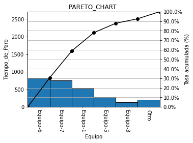

```python
df = final_df.copy()
pareto_chart(df)
```

## 02-02 Diagrama de causa y efecto (Diagrama de Ishikawa

### 1. Diagrama de Ishikawa)

Es un diagrama de muestra de manera clara cómo las causas (factoers) están relacionadas e influyen en el resultado (característica). A veces se le llama Diagrama de Fishbone debido a que su forma se asemeja a la espina de un pescado.

### 2. Cómo hacerlo (1)

#### Paso 1:

Determinar la característica (problema)

#### Paso 2:

Dibuja una flecha principal de izquierda a derecha y escribir en su extremo la característica de calidad identificada.

#### Paso 3:

Escribir los factores principales en huesos grandes (ramas principales) y encerrarlos en un cuadro.

- 4M

#### Paso 4:

Para cada grupo de factores principales, dibujar huesos medianos (raomas secundarias) y agregar factores más pequeños en huesos pequeños (ramas terciarias).

#### Paso 5:

Se deben encerrar en un cuadro o marcar con símbolos como ◎ o 〇 aquellos factores en los extremos que se consideren de mayor impacto.

- Factor importante

#### Paso 6:

Escriba el nombre del diagrama de causa y efecto, la fecha de creación y otros detalles necesarios.

### 3. Método de lluvia de ideas (Brainstorming)

Las cuatro reglas de la lluvia de ideas:

- Prohibido criticar (Prohibición de críticas)
- Libertad total (Expresión líbre)
- Cuantas más ideas, mojor (Generar una gran cantidad de ideas)
- Bienvenidas las ideas complementarias (Aprovechar y desarrolar ideas de otros)

#### Paso 1:

Determinar la característica de calidad (problema)

#### Paso 2:

Realizar una **lluvia de ideas** y escribir en tarjetas los factores que se cree que afectan la característica.

#### Paso 3:

Clasificar las tarjetas.

#### Paso 4:

Crear los huesos principales y armar el digrama de causa y efecto.

#### Paso 5:

Se deben encerrar en un cuadro o marcar con símbolos como ◎ o 〇 aquellos factores en los extremos que se consideren de mayor impacto.

- Factor importante

#### Paso 6:

Escriba el nombre del diagrama de causa y efecto, la fecha de creación y otros detalles necesarios.

### 5. Puntos a tener en cuenta

1. La expresión para representar las características de calidad puede ser simplemente el nombre de la característica, como "defecto de 〇〇" o puede expresa el mal resultado, como "hay muchos defectos de 〇〇".
2. Trata de identificar al menos 30 factores.
3. Se dice que el valor de un diagrama de causa y efecto radica en las pequeñas ramas (ramas secudarias o ramas de los nietos). Es recomendable que, en lugar de tener ramas simples, se hagan ramas más complejas.
4. Al listar los facores, no se indican los niveles. Las caraterísticas de los factores deben estar siempre rodaeadas por un círculo, y la verificación de los factores debe comenzar con los factores clave.
5. Los factores clave deben estar siempre rodeados por un cículo, y la verificación de los factores debe comenzar con los factores clave.

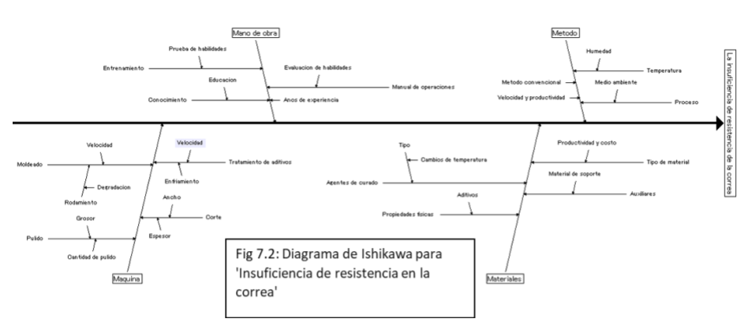

```python
img = Image.open("Graph3/DiagramaDeIshikawa.png")
display(img)
```

## 02-03 Hoja de verificación

### 1. ¿Qué es una hoja de verificación?

Se prepara una hoja impresa con los elementos necesarios de antemano para facilitar el registro de los datos recopilados. De este modo, los resultados de inspección, las verificaciones de trabajo y los registros de prueba pueden regisgrarse fácilmente mediante marcas de verificación.

### 2. Tipos de hojas de verificación

La hoja de verificación se puede clasificar según su propósito de uso de la siguiente manera:

1. Para la investigación de elementos no conformes (defectuosos).
2. Para la investigación de la ubicación de las no conformidades (defectos).
3. Para la investigación de la distribución del proceso.
4. Para la investigación de las causas de las no conformidades (detectos).
5. Para la verifiación y confirmación (lista de verifiación)

### 3. Cómo eleborar una hoja de verificación y cosideraciones importantes

1. Facilitar el registro de datos de manera sencilla.
2. Incluir un espacio para registrar guién, cuándo, cómo y otoros detalles de las 5W1H.
3. Discutir a fondo con los trabajadores para hacerles reconocer la importancia de los datos.
4. Organizar los ítems de trabajo según el orden de las operaciones.
5. Revisar periódicamente los elementos de verificación

### 4. Hoja de verificación para la investigación de elementos no conormes (defectuosos)

Investigar qué tipo de no conformidades (defectos) ocurren y en qué proporción, para tomar medidas a partir de los defectos con mayor proporción de ocurrencia, creando un espacio para vefificar por cada tipo de defecto.

## 02-03 Hoja de verificación

### 1. ¿Qué es una hoja de verificación?

Se prepara una hoja impresa con los elementos necesarios de antemano para facilitar el registro de los datos recopilados. De este modo, los resultados de inspección, las verificaciones de trabajo y los registros de prueba pueden regisgrarse fácilmente mediante marcas de verificación.

### 2. Tipos de hojas de verificación

La hoja de verificación se puede clasificar según su propósito de uso de la siguiente manera:

1. Para la investigación de elementos no conformes (defectuosos).
2. Para la investigación de la ubicación de las no conformidades (defectos).
3. Para la investigación de la distribución del proceso.
4. Para la investigación de las causas de las no conformidades (detectos).
5. Para la verifiación y confirmación (lista de verifiación)

### 3. Cómo eleborar una hoja de verificación y cosideraciones importantes

1. Facilitar el registro de datos de manera sencilla.
2. Incluir un espacio para registrar guién, cuándo, cómo y otoros detalles de las 5W1H.
3. Discutir a fondo con los trabajadores para hacerles reconocer la importancia de los datos.
4. Organizar los ítems de trabajo según el orden de las operaciones.
5. Revisar periódicamente los elementos de verificación

### 4. Hoja de verificación para la investigación de elementos no conormes (defectuosos)

Investigar qué tipo de no conformidades (defectos) ocurren y en qué proporción, para tomar medidas a partir de los defectos con mayor proporción de ocurrencia, creando un espacio para vefificar por cada tipo de defecto.

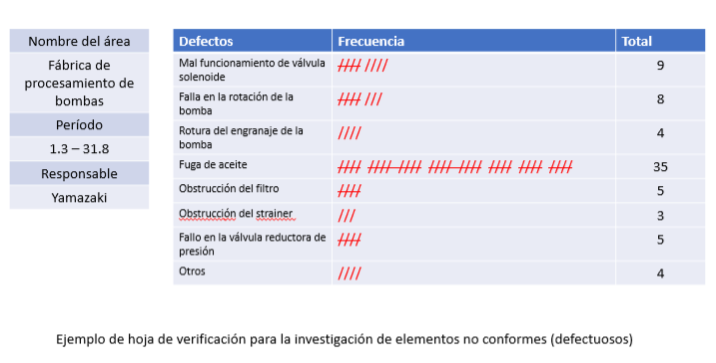

```python
img = Image.open("Graph3/Hoja de verificación.png")
display(img)
```

### 5. Hoja de verificación para la investigación de la ubicación de las no conformidades (defectos)

Investigar en qué áreas de piezas o productos terminados ocurren los defectos, así como en qué áreas de las habitaciones o comedores se presentan suciedad o daños, marcando en los diagramas de los productos o en los planos de las habitaciones para recopilar los datos.

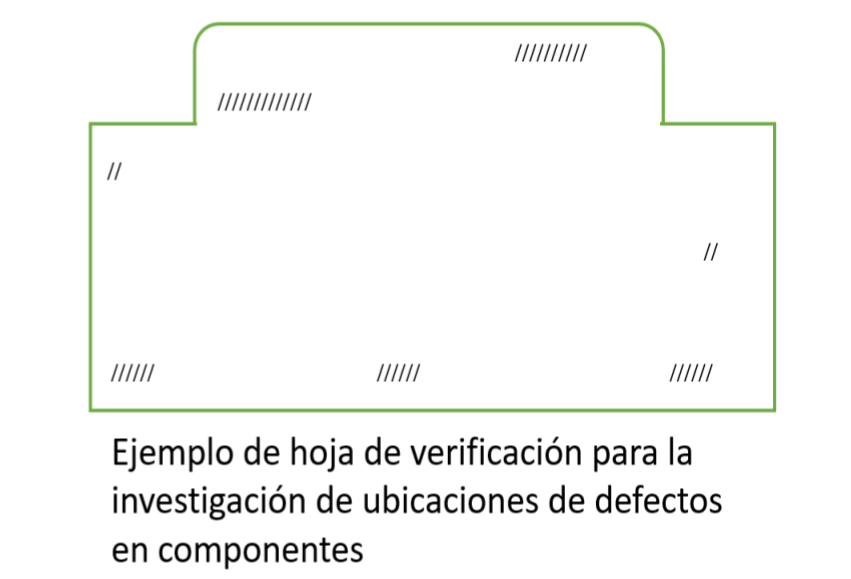

```python
img = Image.open("Graph3/Hoja de verificación para la investigación de la ubicación de las no conformidades (defectos).png")
display(img)
```

### 6. Hoja de verificación para la investigación de la distribución del proceso

Cuando se desea conocer cómo varían los datos como el peso y las dimensiones de la piezas, el tiempo de procesamiento, y si se producen valores fuera de especificación, se deben registrar previamente los valores necesarios y los valores de especificación, y marcar en la casilla correspondiente cada vez que se obtengan los datos.

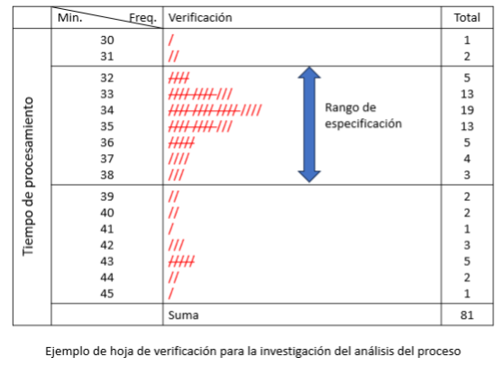

```python
img = Image.open("Graph3/Hoja de verificacion_6 (1).png")
display(img)
```

### 7. Hoja de verificación para la investigación de las causas de las no conformidades (defectos)

Cuando hay múltiples factores (causas) de defectos, se consolidan en una sola hora de verificación para identificarlos y comprender sus causas.

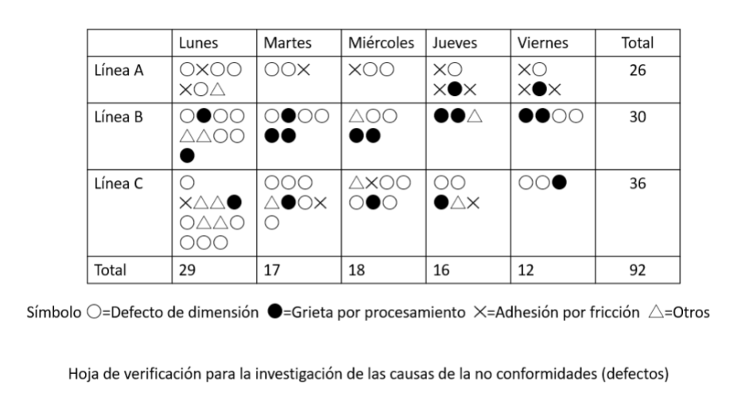

```python
img = Image.open("Graph3/Hoja de verificación 7.png")
display(img)
```

### 8. Hoja de verificacón para la inspección y confirmación

```
Ejemplo de una hoja de verificación para inspección
```

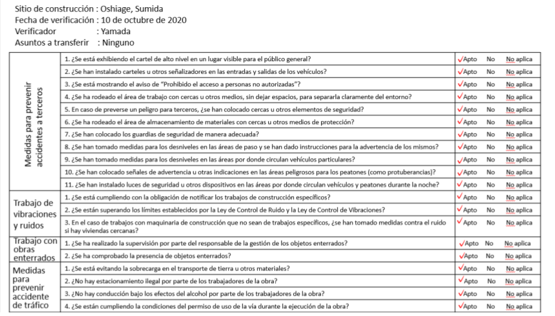

```python
print("Ejemplo de una hoja de verificación para inspección")

img = Image.open("Graph3/Hoja de verificación 8.png")
display(img)
```

## 02-04 Histograma

### 1. ¿Qué es un histograma?

- Un gráfico en forma de barras que muestra de manera clara la distribución de los datos medidos, como la longitud, el tiempo y la dureza.

### 2. Cómo hacer un histgrama

- Establecer un período y recopilar datos. Es recomendable tener al menos 50 datos, y preferiblenmente alrededor de 100.
- Determinar el número provisional de intervalos c
  - $ c = \sqrt{n} $
    - n = Cantidad de datos
- Establecer los límites superior e inferior de especificación

## 2.2

ゴムパッキンの厚さを測定したデータが１００個ある（表2.4）

1. ヒストグラムを作成せよ
2. 平均値、標準偏差を計算せよ

Se tienen 100 datos de medición del grosor de una junta de goma (Tabla 2.4)

- Elabore un histograma
- Calcule el valor medio y desviación estándar

```python
sheet = client.open_by_key(SPREADSHEET_ID).worksheet("Sheet9") # 最初のシートを取得

# データを取得
list_of_lists = sheet.get_all_records()
df = pd.DataFrame(list_of_lists)

df.columns = df.iloc[0]
df.reset_index(drop=True, inplace=True)

df = df.astype('float')

print('Tabla 2.4 Espesor de la junta de goma')
thickness_data = df.to_numpy().reshape(10,10)
thickness_data.tolist()
```

```
Tabla 2.4 Espesor de la junta de goma
```

```
[[64.9, 70.2, 74.8, 69.2, 69.9, 70.3, 67.9, 70.4, 71.7, 70.3],
 [73.0, 69.7, 69.0, 69.2, 71.7, 68.3, 65.9, 75.3, 70.7, 73.6],
 [72.2, 74.0, 70.9, 73.0, 72.2, 74.0, 76.2, 77.7, 70.1, 68.8],
 [68.0, 72.0, 70.4, 67.8, 71.5, 69.9, 72.5, 69.3, 69.3, 67.3],
 [68.3, 69.1, 75.0, 72.1, 68.1, 67.4, 70.7, 71.2, 74.3, 67.7],
 [71.5, 64.9, 75.5, 72.0, 69.4, 69.3, 64.6, 68.0, 66.2, 66.3],
 [69.2, 76.2, 75.4, 68.7, 71.7, 70.2, 62.6, 70.7, 69.8, 70.2],
 [70.8, 73.7, 64.6, 67.1, 66.0, 68.7, 73.4, 68.9, 71.9, 68.7],
 [70.7, 70.4, 70.7, 75.7, 66.7, 66.6, 69.8, 66.7, 73.1, 73.8],
 [72.6, 70.7, 75.0, 68.6, 72.1, 64.8, 71.8, 67.7, 67.6, 75.7]]
```

```
Media: 70.34
Desviación estándar: 3.04
[62.  63.5 65.  66.5 68.  69.5 71.  72.5 74.  75.5 77.  78.5]
```

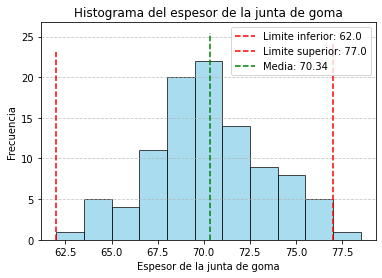

```python
data_flat = thickness_data.flatten()

def histograma(data_flat, lower_limit, upper_limit):
    mu = np.mean(data_flat)
    s = np.std(data_flat,ddof=True)

    print(f"Media: {mu:.2f}")
    print(f"Desviación estándar: {s:.2f}")

    # Determinar un intervalo provisional c
    c = np.sqrt(len(data_flat)).astype(int)

    # Límite superior, Límite interior
    lower_limit = lower_limit
    upper_limit = upper_limit

    #
    dmax = data_flat.max()
    dmin = data_flat.min()
    dkan = (upper_limit - lower_limit)/c

    #
    arr = np.linspace(lower_limit, upper_limit, (c+1))

    while np.min(arr) > dmin:
        arr = np.insert(arr, 0, np.min(arr) - dkan)

    while np.max(arr) < dmax:
        arr = np.append(arr, (np.max(arr) + dkan))

    print(arr)

    # Creación de un histograma
    plt.hist(data_flat, bins=arr, color='skyblue', edgecolor='black', alpha=0.7)
    plt.vlines(x=lower_limit, ymin=0, ymax=plt.ylim()[1], colors='red', linestyles='dashed', label=f'Limite inferior: {lower_limit:.1f}')
    plt.vlines(x=upper_limit, ymin=0, ymax=plt.ylim()[1], colors='red', linestyles='dashed', label=f'Limite superior: {upper_limit:.1f}')
    plt.vlines(x=mu, ymin=0, ymax=plt.ylim()[1], colors='green', linestyles='dashed', label=f'Media: {mu:.2f}')

    plt.legend()
    plt.xlabel("Espesor de la junta de goma")
    plt.ylabel("Frecuencia")
    plt.title("Histograma del espesor de la junta de goma")
    plt.grid(axis='y', linestyle='--', alpha=0.7)
    plt.show()


histograma(data_flat, 62, 77)
```

### 3. Observar el estado de la distribución a partir de la forma del histograma

#### Forma general (tipo normal)

- Forma de la distribución normal

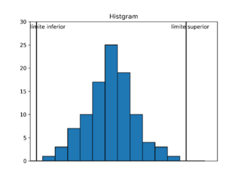

```python
img = Image.open("Graph3/Histgram1.png")
display(img)
```

### Tipo con juecos

- Es común que haya problemas en la forma de organizar

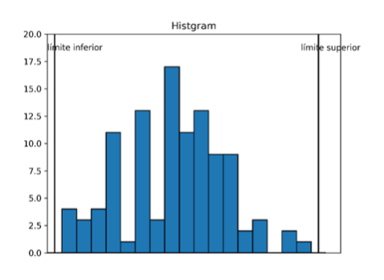

```python
img = Image.open("Graph3/Histgram2.png")
display(img)
```

### Forma de dos picos

- Existen dos distribuciones con mdedias diferentes.

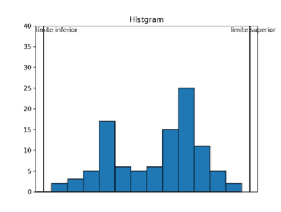

```python
img = Image.open("Graph3/Histgram3.png")
display(img)
```

### Forma de islas dispersas

- Es común que la distribución tenga forma de islas dispersas debido a anomalías en el proceso, contaminaciín de muestras diferentes o errores en la medición.

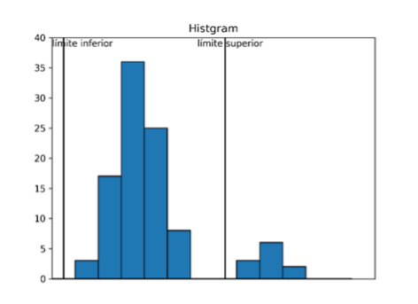

```python
img = Image.open("Graph3/Histgram4.png")
display(img)
```

### Forma de acantilado

- Se han elimado los elementos fuera de especificación

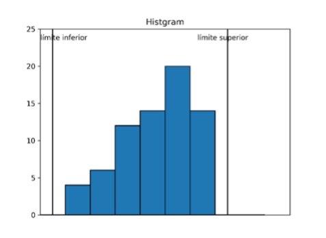

```python
img = Image.open("Graph3/Histgram5.png")
display(img)
```

### 4. Comparación rentre el histograma y los valores de especificación

- La capacidad del proceso es aceptable

```
Media: 70.34
Desviación estándar: 3.04
[60. 62. 64. 66. 68. 70. 72. 74. 76. 78. 80.]
```

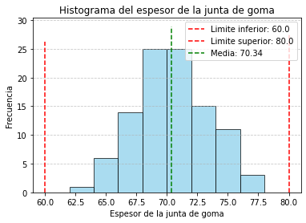

```python
histograma(data_flat, 60, 80)
```

- Es necesario reducir más la variablidad

```
Media: 70.34
Desviación estándar: 3.04
[62. 63. 64. 65. 66. 67. 68. 69. 70. 71. 72. 73. 74. 75. 76. 77. 78.]
```

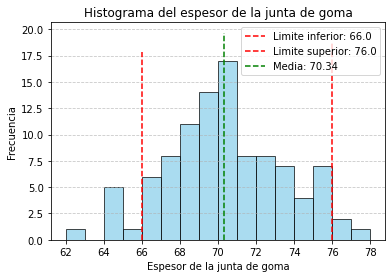

```python
histograma(data_flat, 66, 76)
```

- Como la media se ha desplazado hacía el lado mayor, están apareciendo productos defectuosos

```
Media: 70.34
Desviación estándar: 3.04
[50.  52.5 55.  57.5 60.  62.5 65.  67.5 70.  72.5 75.  77.5 80. ]
```

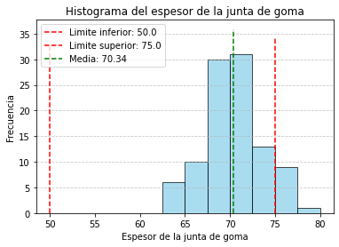

```python
histograma(data_flat, 50, 75)
```

## 02-05 Diagrama de dispersión

### 1. Diagrama de dispersión

- Un gráfico que representa los datos emparejados como puntos para investigar la ralación de correlación entre dos tipos de datos.

### 2. Creación del digagrama de dispersión

- La Figura 2.13 muestra un diagrama de dispersión entre el porcentaje de cantidad de aditivo $ x $ (%) añadido a una lámina de resina y la transmitacia de luz (porcentaje de transparencia $ y $ (%) de la lámina de resina).

```
Coeficiente de correlación:, 0.51
```

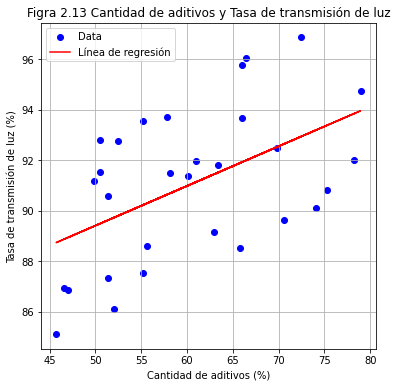

```python
# Data
np.random.seed(42)

# x: Cantidad de aditivos
x = np.random.uniform(45, 80, 30)

# y: Tasa de transmisión
y = 0.2 * x + np.random.uniform(85, 93, 30) - 10

# Coeficiente de correlación
correlation_matrix = np.corrcoef(x, y)
correlation_coefficient = correlation_matrix[0, 1]

print(f"Coeficiente de correlación:, {correlation_coefficient:.2f}")

# Creación del diagrama de dispersión
plt.figure(figsize=(6, 6))
plt.scatter(x, y, color='blue', label='Data')

#
plt.xlabel('Cantidad de aditivos (%)')
plt.ylabel('Tasa de transmisión de luz (%)')
plt.title('Figra 2.13 Cantidad de aditivos y Tasa de transmisión de luz')


plt.grid(True)

# Linea de regresión
m, b = np.polyfit(x, y, 1)  #
plt.plot(x, m*x + b, color='red', label='Línea de regresión')

plt.legend()

plt.show()
```

### 3. Uso del diagrama de dispersión

1. Observar la relación de correlación
2. Observar la necesidad de puntos atípicos y estratificación
3. Realizar un análisis de correlación

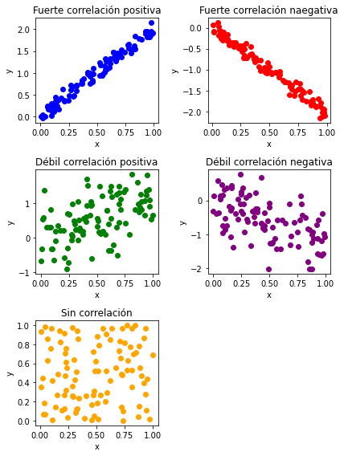

```python
np.random.seed(0)

# 1. Fuerte correlación positiva
x1 = np.random.rand(100)
y1 = 2 * x1 + np.random.normal(0, 0.1, 100)

# 2. Fuerte correlación negativa
x2 = np.random.rand(100)
y2 = -2 * x2 + np.random.normal(0, 0.1, 100)

# 3. Débil correlación posiriva
x3 = np.random.rand(100)
y3 = 1.2 * x3 + np.random.normal(0, 0.5, 100)

# 4. Débil corrlación negativa
x4 = np.random.rand(100)
y4 = -1.2 * x4 + np.random.normal(0, 0.5, 100)

# 5. Sin correlación
x5 = np.random.rand(100)
y5 = np.random.rand(100)

#
fig, axs = plt.subplots(3, 2, figsize=(6, 8))
axs[0, 0].scatter(x1, y1, color='blue')
axs[0, 0].set_title("Fuerte correlación positiva")
axs[0, 0].set_xlabel("x")
axs[0, 0].set_ylabel("y")

axs[0, 1].scatter(x2, y2, color='red')
axs[0, 1].set_title("Fuerte correlación naegativa")
axs[0, 1].set_xlabel("x")
axs[0, 1].set_ylabel("y")

axs[1, 0].scatter(x3, y3, color='green')
axs[1, 0].set_title("Débil correlación positiva")
axs[1, 0].set_xlabel("x")
axs[1, 0].set_ylabel("y")

axs[1, 1].scatter(x4, y4, color='purple')
axs[1, 1].set_title("Débil correlación negativa")
axs[1, 1].set_xlabel("x")
axs[1, 1].set_ylabel("y")

axs[2, 0].scatter(x5, y5, color='orange')
axs[2, 0].set_title("Sin correlación")
axs[2, 0].set_xlabel("x")
axs[2, 0].set_ylabel("y")

#
axs[2, 1].axis('off')

#
plt.tight_layout()

#
plt.show()
```

## 02-06 Gráfico

### 1. Gráfico

- Un gráfico es una representación de datos organizados según el tamaño de los valores o cantidades, la desagregación, los cambios temporales, etc., y se muestra mediante la altura de las líneas o barras, el área de las figuras, entre otros.

### 2. Gráfico de barras

- Se compara el tamaño de las cantidades mediante la altura de las barras de un ancho fijo. En los gráficos de barras, existen gráficos de barras verticales, donde las barras están dispuestas de forma vertical, y gfáficos de barras horizontales, donde las barras están dispuestas de forma horizontel.

La tabla muestra los seis principales tipos de verduras con mayor volumen de importación en Japón en 2018. Se creará un gráfico de barras.

```python
sheet = client.open_by_key(SPREADSHEET_ID).worksheet("Sheet10") # 最初のシートを取得

# データを取得
list_of_lists = sheet.get_all_records()
df = pd.DataFrame(list_of_lists)

df["Importación"] = df["Importación"].astype('float')

df2 = df.copy()
df2["ratio"] = np.round((df2["Importación"] / df2["Importación"].sum())*100,1)
df2 = df2.T
df2.columns = df2.iloc[0]
df2 = df2.drop(df2.index[0])
df2["Total"]= df2.sum(axis=1)
df2.iloc[1,6]= 100.0

df2
```

| Verdura | Cebolla | Zanahoria | Calabaza | Repollo | Puerro | Burdock | Total |
| --- | --- | --- | --- | --- | --- | --- | --- |
| Importación | 297256.0 | 110578.0 | 103170.0 | 92357.0 | 66905.0 | 49078.0 | 719344.0 |
| ratio | 41.3 | 15.4 | 14.3 | 12.8 | 9.3 | 6.8 | 100.0 |

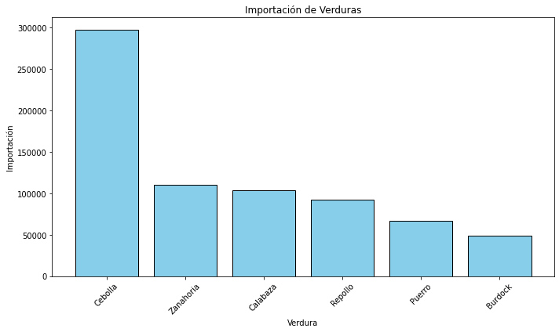

```python
# Gráfico de barras
plt.figure(figsize=(10, 6))
plt.bar(df['Verdura'], df['Importación'], color='skyblue', edgecolor='black')
plt.title('Importación de Verduras')
plt.xlabel('Verdura')
plt.ylabel('Importación')
plt.xticks(rotation=45)  #
plt.tight_layout()
plt.show()
```

#### 3.Gráfico circular / Gráfico de pastel

- Un gráfico circular representa el total en forma de un círculo o un anillo (circulo doble) y lo divide en varias secciones, comparando la proporción de cada elemento según el tamaño de cada segmento.

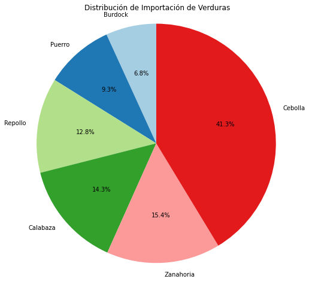

```python
df_sorted = df.sort_values('Importación', ascending=True)

# Gráfico circular
plt.figure(figsize=(8, 8))
plt.pie(df_sorted['Importación'], labels=df_sorted['Verdura'], autopct='%1.1f%%', startangle=90, colors=plt.cm.Paired.colors)
plt.title('Distribución de Importación de Verduras')
plt.axis('equal')  #
plt.show()
```

### 4. Gráfico de líneas

- Un gráfico de líneas generalmente representa en el eje vertical una cantidad y en el eje horizontal el tiempo (días, meses, años, etc.en serie temporal). Al conectar los puntos con una línea, se puede visualizar el estado de la cantidad que varía con el tiempo.

```python
sheet = client.open_by_key(SPREADSHEET_ID).worksheet("Sheet11")
list_of_lists = sheet.get_all_records()
df = pd.DataFrame(list_of_lists)

df = df.set_index("Año")
df.index = df.index.astype(str)
df = df.astype('float')
data = df.to_dict()

df
```

| Año | Manzana | Mandarina | Castaña | Pera | Durazno |
| --- | --- | --- | --- | --- | --- |
| 2001 | 2175.0 | 5358.0 | 33.0 | 2860.0 | 10.0 |
| 2007 | 25728.0 | 4557.0 | 2082.0 | 799.0 | 488.0 |
| 2013 | 19731.0 | 2830.0 | 1314.0 | 1246.0 | 578.0 |

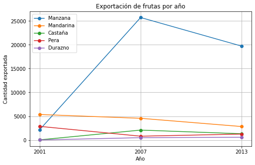

```python
df.index = df.index.astype(str)

# Creación de un gráfico de línea
plt.figure(figsize=(8, 5))
for column in df.columns:
    plt.plot(df.index, df[column], marker='o', label=column)

plt.xlabel("Año")
plt.ylabel("Cantidad exportada")
plt.title("Exportación de frutas por año")
plt.legend()
plt.grid(True)

plt.show()
```

### 5. Gráfico de áreas / Gráfico de bandas

- El gráfico de bandas representa el total mediante la longitud de una banda rectangular y se divide según la proporción de cada elemento. Estas bandas se disponen verticalmente y se utilizan comúnmente para observar los cambios a lo largo del tiempo.

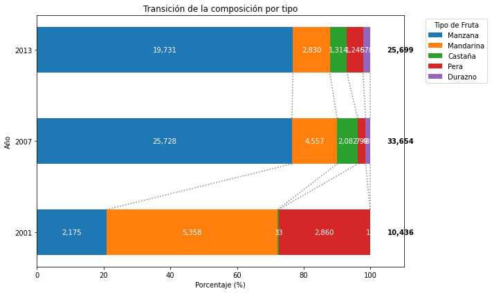

```python
years = ['2001', '2007', '2013']
labels = list(data.keys())
values = {year: [data[fruit][year] for fruit in labels] for year in years}

total_values = {year: sum(values[year]) for year in years}
ratios = {year: [v / total_values[year] * 100 for v in values[year]] for year in years}

fig, ax = plt.subplots(figsize=(10, 6))
height = 0.5  # Bar height
bottom = np.zeros(len(years))
bar_positions_upper = {fruit: [] for fruit in labels}  # Store upper positions for dotted lines
bar_positions_lower = {fruit: [] for fruit in labels}  # Store lower positions for dotted lines

for fruit in labels:
    bars = ax.barh(years, [ratios[year][labels.index(fruit)] for year in years], height, label=fruit, left=bottom)
    for bar, year in zip(bars, years):
        value = ratios[year][labels.index(fruit)]
        val = values[year][labels.index(fruit)]
        ax.text(bar.get_x() + bar.get_width() / 2, bar.get_y() + bar.get_height() / 2, f'{int(val):,}', ha='center', va='center', color='white', fontsize=10)
        bar_positions_upper[fruit].append(bar.get_x() + bar.get_width())
        bar_positions_lower[fruit].append(bar.get_x())
    bottom += np.array([ratios[year][labels.index(fruit)] for year in years])

# Add dotted lines at the top and bottom of each band
for fruit in labels:
    for i in range(len(years) - 1):
        x1_upper, x2_upper = bar_positions_upper[fruit][i], bar_positions_upper[fruit][i + 1]
        x1_lower, x2_lower = bar_positions_lower[fruit][i], bar_positions_lower[fruit][i + 1]
        y1_upper, y2_upper = i + 0.5 * height, i + 1 + 0.5 * height  # Adjusted to top of the band
        y1_lower, y2_lower = i - 0.5 * height, i + 1 - 0.5 * height  # Adjusted to bottom of the band
        ax.plot([x1_upper, x2_upper], [y1_upper, y2_lower], 'gray', linestyle='dotted')

# Add total values to the right of the bars
for i, year in enumerate(years):
    ax.text(105, i, f'{total_values[year]:,.0f}', va='center', fontsize=10, fontweight='bold')

ax.set_xlabel("Porcentaje (%)")
ax.set_ylabel("Año")
ax.set_title("Transición de la composición por tipo")
ax.legend(title="Tipo de Fruta", bbox_to_anchor=(1.05, 1), loc='upper left')
plt.yticks(rotation=0)
plt.xlim(0, 110)
plt.tight_layout()
plt.show()
```

### 6. Gráfico de radar

- El gráfico radar es una figura de polígono regular en la que se extienden líneas radiales seguún el número de categorías. La posición de los puntos según la longitud de las líneas permite comprender el nivel y el equilibrio de cada componente.

Se muestra un gráfico radar de la tasa de mortalidad por cáncer la ubicación en fumadores, tomando a los no fumadores como el 100%. Del gráfico se puede observar que las tasas de mortalidad por cáncer de pulmón y esófago son más altos en los fumadores.

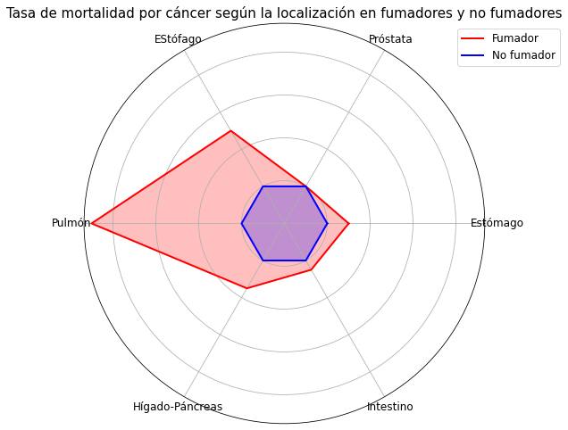

```python
from math import pi

# Tasa de mortalidad por cáncer según la localización（Fumador y No fumador）
cancer_sites = ['Estómago', 'Próstata', 'EStófago', 'Pulmón', 'Hígado-Páncreas', 'Intestino']
non_smoker_rates = [100, 100, 100, 100, 100, 100]  # No fumador
smoker_rates = [150, 100, 250, 450, 175, 125]    # Fumadaor

angles = np.linspace(0, 2 * np.pi, len(cancer_sites), endpoint=False).tolist()

smoker_rates += smoker_rates[:1]
non_smoker_rates += non_smoker_rates[:1]
angles += angles[:1]


fig, ax = plt.subplots(figsize=(8, 8), subplot_kw=dict(polar=True))

# Grafical los datos de los fumadores
ax.plot(angles, smoker_rates, linewidth=2, linestyle='solid', label='Fumador', color='red')

# Grafical los datos de los no fumadores
ax.plot(angles, non_smoker_rates, linewidth=2, linestyle='solid', label='No fumador', color='blue')

ax.fill(angles, smoker_rates, color='red', alpha=0.25)
ax.fill(angles, non_smoker_rates, color='blue', alpha=0.25)

ax.set_yticklabels([])
ax.set_xticks(angles[:-1])
ax.set_xticklabels(cancer_sites, fontsize=12)

#
ax.set_title('Tasa de mortalidad por cáncer según la localización en fumadores y no fumadores', size=15)
ax.legend(loc='upper right', bbox_to_anchor=(1.2, 1), fontsize=12)

plt.tight_layout()
plt.show()
```

## 2.3

表2.8 はW中学校で行った、Aさん、Bさん、Cさん、Dさんの体力テストの結果である。レーダーチャートを作成せよ。

La tabla 2.8 muestra los resultados de las pruebas de aptitud física realizadas en la escuela secundaria W para las personas A, B, C y D. Crea un gráfico radar.

```python
sheet = client.open_by_key(SPREADSHEET_ID).worksheet("Sheet12") # 最初のシートを取得

# データを取得
list_of_lists = sheet.get_all_records()
df = pd.DataFrame(list_of_lists)

df.set_index(['Nombre del estudiante'], inplace=True)
df = df.astype('int')
data = df.to_dict()

df["Puntos mutuos"] = df.sum(axis=1)
mean_values = df.mean()
df.loc["Puntuacion media"] = mean_values
df.iloc[4,6]="-"

print("Tabla 2.8 ")
df
```

```
Tabla 2.8
```

| Nombre del estudiante | Salto vertical | Salto lateral repetido | Dribbling en zig-zag | Flexión del tronco hacia adelante | Subir y bajr escalón | Fuerza muscular | Puntos mutuos |
| --- | --- | --- | --- | --- | --- | --- | --- |
| A | 4.00 | 4.00 | 4.0 | 3.00 | 4.00 | 3.00 | 22.0 |
| B | 3.00 | 3.00 | 5.0 | 3.00 | 4.00 | 2.00 | 20.0 |
| C | 3.00 | 3.00 | 3.0 | 2.00 | 4.00 | 5.00 | 20.0 |
| D | 5.00 | 5.00 | 4.0 | 3.00 | 3.00 | 3.00 | 23.0 |
| Puntuacion media | 3.75 | 3.75 | 4.0 | 2.75 | 3.75 | 3.25 | - |

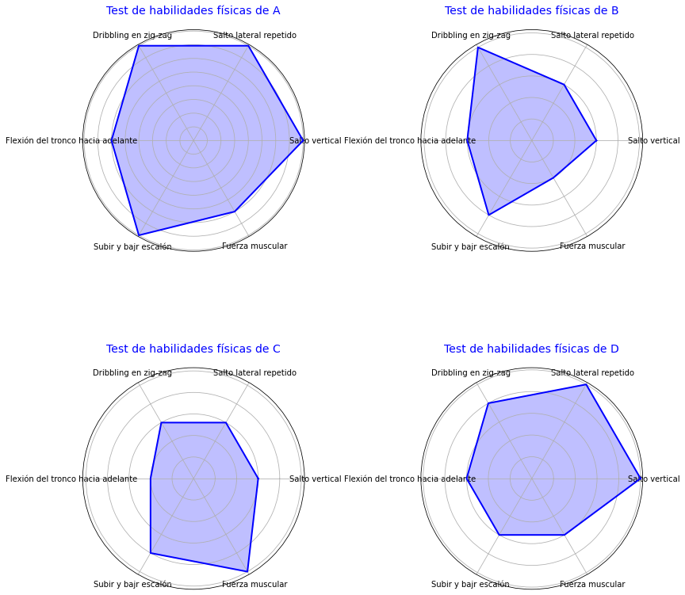

```python
# Data
categories = data.keys()
results = {'A': [], 'B': [], 'C': [], 'D': []}

for category in categories:
    values = data[category]
    for key in results:
        results[key].append(values[key])

fig, axes = plt.subplots(2, 2, figsize=(12, 12), subplot_kw=dict(polar=True))

# Función para dibujar el gráfico radar
def create_radar_chart(ax, student_name, values):
    values = values + [values[0]]
    angles = np.linspace(0, 2 * np.pi, len(categories), endpoint=False).tolist()
    angles += angles[:1]

    ax.fill(angles, values, color='blue', alpha=0.25)
    ax.plot(angles, values, color='blue', linewidth=2)
    ax.set_yticklabels([])
    ax.set_xticks(angles[:-1])
    ax.set_xticklabels(categories, fontsize=10)
    ax.set_title(f'Test de habilidades físicas de {student_name}', size=14, color='blue', pad=20)

# Gráfico radar de cada estudiante
students = ['A', 'B', 'C', 'D']
for i, student in enumerate(students):
    row = i // 2  #
    col = i % 2   #
    create_radar_chart(axes[row, col], student, results[student])

plt.tight_layout()
plt.show()
```

### 7. Gráfico de Gantt

- El gráfico de Gantt es un gráfico utilizado para la planificación y getión de fechas, donde se colocan las tareas en el eje vertical y las fechas en el eje horizontal, representando tanto los planes como los resultados.

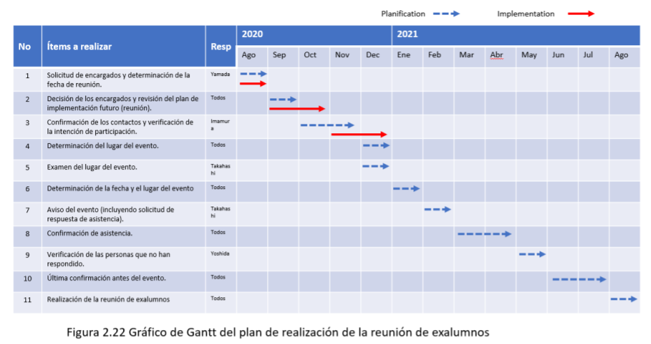

```python
img = Image.open("Graph3/Gantt.png")
display(img)
```

### 8. Puntos a tener en cuenta

1. Al crear el gráfico, es necesario incluir siempre los elementos esenciales como los nombres de los ejes, los nombres de los ítems, las escalas, los valores de las escalas y las unidades.
2. El título del gráfico, la fecha, el nombre del autor y las explicaciones deben escribirse en el espacio en blanco del gráfico o fuera del mismo.
3. Si hay demasiados ítems con valores pequeños, el gráfico puede volverse poco atractvo. En este caso, es mejor agruparlos bajo la categoría Otros.
4. Es recomendable diferenciar y hacer resaltar los ítems o partes que se deseen destacar mediante sombreado o colorado.
5. Los números representados en el gráfico deben tener generalmente tres cifras significativas.

## 02-07 Estratificación

### 1. La estratificación es

La estratificación es el proceso de dividir una gran cantidad de datos en varios grupos según sus características, como por máquina, por material o por operario.

### 2. Los elementos que se estratifican

- Por operario / Por trabajador
- Por máquina / Por equipo
- Por materia prima / Por material
- Por tiempo
- Por métode de trabajo
- Por entorno / Por condiciones ambietales
- Por inspección / Por medición

### 3. Puntos a tener en cuenta

1. Para facilitar la estratificación, es importente aclarar el historial de los datos.
2. Se debe intentar estratificar según diversos criterios.

### 4. Ejemplos de implementación de estratificación

#### 1. Ejempro de aplicación de la estratificación en un histograma.

Este es un hitograma creado para las dimensiones. Se puede observar que la distribución tiene dos picos. Por lo tanto, se reazlizó una estratificación por la Máquina 1 y la Máquina 2 y se crearon hitogramas separados. No hay una diferencia significativa en la dispersión de ambas, pero se puede ver que la Máquina 1 tiene un promedio más bajo que la Máquina 2.

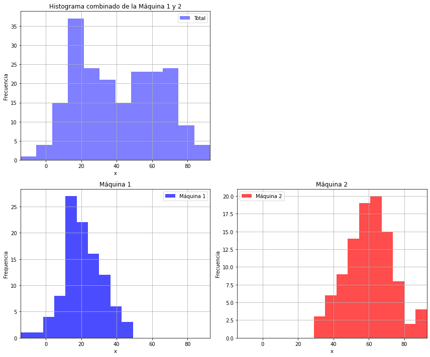

```python
# Datos de muestra de los valores característicos de la Máquina 1 y 2
np.random.seed(5)  #
a_values = np.random.normal(loc=20, scale=12, size=100)  #
b_values = np.random.normal(loc=60, scale=13, size=100)  #

#
min_value = min(np.min(a_values), np.min(b_values))
max_value = max(np.max(a_values), np.max(b_values))

#
fig, axs = plt.subplots(2, 2, figsize=(12, 10))

# Máquina 1
axs[1, 0].hist(a_values, bins=10, alpha=0.7, color='blue', label='Máquina 1')
axs[1, 0].set_title('Máquina 1')
axs[1, 0].set_xlabel('x')
axs[1, 0].set_ylabel('Frequencia')
axs[1, 0].legend()
axs[1, 0].grid(True)
axs[1, 0].set_xlim(min_value, max_value)

# Máquina 2
axs[1, 1].hist(b_values, bins=10, alpha=0.7, color='red', label='Máquina 2')
axs[1, 1].set_title('Máquina 2')
axs[1, 1].set_xlabel('x')
axs[1, 1].set_ylabel('Frecuencia')
axs[1, 1].legend()
axs[1, 1].grid(True)
axs[1, 1].set_xlim(min_value, max_value)

# Histograma combinado de la Máquina 1 y 2
all_values = np.concatenate([a_values, b_values])  #
axs[0, 0].hist(all_values, bins=12, alpha=0.5, color='blue', label='Total')
axs[0, 0].set_title('Histograma combinado de la Máquina 1 y 2')
axs[0, 0].set_xlabel('x')
axs[0, 0].set_ylabel('Frecuencia')
axs[0, 0].set_xlim(min_value, max_value)
axs[0, 0].legend()
axs[0, 0].grid(True)

#
axs[0, 1].axis('off')  #

plt.tight_layout()
plt.show()
```

#### 2. Ejemplo de aplicación de la estratificación en un diagrama de Pareto

El pintado de las placas de acero se raaliza en dos líneas. Se decidió analizar el contenido de los productos no conformes de un mes mediante un diagrama de Pareto.

```python
sheet = client.open_by_key(SPREADSHEET_ID).worksheet("Sheet14") # 最初のシートを取得

# データを取得
list_of_lists = sheet.get_all_records()
df = pd.DataFrame(list_of_lists)

df.reset_index(drop=True, inplace=True)

df = df.set_index('Ítem no conforme')
df = df.astype('float')

dfA = df.copy()
```

```python
sheet = client.open_by_key(SPREADSHEET_ID).worksheet("Sheet15") # 最初のシートを取得

# データを取得
list_of_lists = sheet.get_all_records()
df = pd.DataFrame(list_of_lists)


df.reset_index(drop=True, inplace=True)

df = df.set_index('Ítem no conforme')
df = df.astype('float')

dfB = df.copy()
```

```python
df_merge = pd.merge(dfA, dfB, left_index=True, right_index=True, suffixes=('_A', '_B'))
df_merge['Número de ítems no conformes'] = df_merge['Número de ítems no conformes_A']+df_merge['Número de ítems no conformes_B']

# Ordenar de mayor a monor de Número de ítems no conformes
df_except_last = df_merge[:-1]
df_sorted = df_except_last.sort_values(by='Número de ítems no conformes', ascending=False)
df_merge = pd.concat([df_sorted, df_merge[-1:]])

# Caluclar la acumulación
df_merge['Número acumulado de ítems no conformes'] = df_merge['Número de ítems no conformes'].cumsum()

# Calcular la proporción
df_merge['Tasa (%)'] = np.round(df_merge['Número de ítems no conformes'] / df_merge['Número de ítems no conformes'].sum() * 100,1)

# Calcular la proporción acumulada
df_merge['Tasa acumulada (%)'] = np.round(df_merge['Número de ítems no conformes'].cumsum() / df_merge['Número de ítems no conformes'].sum() * 100,1)

dfC = df_merge[['Número de ítems no conformes','Número acumulado de ítems no conformes','Tasa (%)','Tasa acumulada (%)']]
```

1. Al crear un diagrama de Pareto del contenido de productos no conformes en ambas líneas en su conjunto, no se encontraron diferencias en los distrintos tipos de defectos.

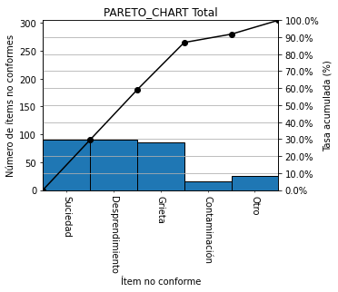

```python
pareto_chart(dfC, "Total")
```

Se realizó la estratificación por la Línea A y la Línea B y se crearon diagramas de Pareto para cada una. Como resultado, se enconró que en la Línea A, "desgualdad en el color" y "suciedad" representaban aproximadamente el 70% del total, mientras que en la Linea B, " desprendimento" y "grietas" constituían el mismo porcentaje. Por lo tanto, se decidió investigar las causas de estos dos principales defectos en cada línea.

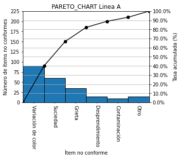

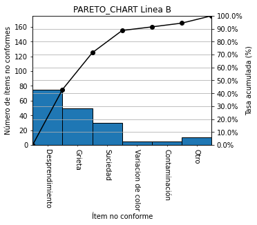

```python
pareto_chart(dfA, "Linea A")
pareto_chart(dfB, "Linea B")
```

#### 3. Ejemplo de aplicación de la estratificación en un diagrama de dispersión

Es una representación de la ralación entre el número de visitantes y las ventas de un día en un centro comercial.

En general parece que **no hay correlación**, pero al estratificar y graficar los productos de bajo precio y uso general (Producto A: circulo azul) y los productos de alto precio y preferencia (Product B: círculo rojo), se observa que el Producto A tiene una **correlación positiva** entre el número de visitantes y las ventas. Por otro lado, el Producto B parece **no tener una relación de correlación**.

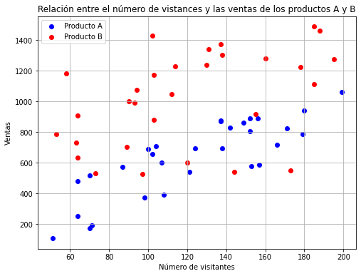

```python
np.random.seed(42)
n = 30

# Product A（Correlación positiva）
x_a = np.random.randint(50, 200, n)  #
y_a = x_a * 5 + np.random.randint(-200, 200, n)  #

# Product B（Sin correlación)
x_b = np.random.randint(50, 200, n)
y_b = np.random.randint(500, 1500, n)  #

# Creación de diagrama de dispersión
plt.figure(figsize=(8, 6))
plt.scatter(x_a, y_a, color='blue', label="Producto A")
plt.scatter(x_b, y_b, color='red', label="Producto B")

# Graph
plt.xlabel("Número de visitantes")
plt.ylabel("Ventas")
plt.title("Relación entre el número de vistances y las ventas de los productos A y B")
plt.legend()
plt.grid(True)
plt.show()
```

```python
notebook_name = 'QCKentei3-2.ipynb'
notebook_name_html = notebook_name.replace(".ipynb",".html")

!jupyter nbconvert --to html {notebook_name}
```

```
[NbConvertApp] Converting notebook QCKentei3-2.ipynb to html
[NbConvertApp] Writing 2235495 bytes to QCKentei3-2.html
```